# MovieLens Project Question Notebook_Final

### `Project - MovieLens Data Analysis`

The GroupLens Research Project is a research group in the Department of Computer Science and Engineering at the University of Minnesota. The data is widely used for collaborative filtering and other filtering solutions. However, we will be using this data to act as a means to demonstrate our skill in using Python to “play” with data.

### `Objective:`

- To implement the techniques learnt as a part of the course.

### `Datasets Information:`

rating CSV = data.csv

*rating.csv:* It contains information on ratings given by the users to a particular movie.

- user id: id assigned to every user
- movie id: id assigned to every movie
- rating: rating given by the user
- timestamp: Time recorded when the user gave a rating

*movie.csv:* File contains information related to the movies and their genre.

- movie id: id assigned to every movie
- movie title: Title of the movie
- release date: Date of release of the movie
- Action: Genre containing binary values (1 - for action 0 - not action)
- Adventure: Genre containing binary values (1 - for adventure 0 - not adventure)
- Animation: Genre containing binary values (1 - for animation 0 - not animation)
- Children’s: Genre containing binary values (1 - for children's 0 - not children's)
- Comedy: Genre containing binary values (1 - for comedy 0 - not comedy)
- Crime: Genre containing binary values (1 - for crime 0 - not crime)
- Documentary: Genre containing binary values (1 - for documentary 0 - not documentary)
- Drama: Genre containing binary values (1 - for drama 0 - not drama)
- Fantasy: Genre containing binary values (1 - for fantasy 0 - not fantasy)
- Film-Noir: Genre containing binary values (1 - for film-noir 0 - not film-noir)
- Horror: Genre containing binary values (1 - for horror 0 - not horror)
- Musical: Genre containing binary values (1 - for musical 0 - not musical)
- Mystery: Genre containing binary values (1 - for mystery 0 - not mystery)
- Romance: Genre containing binary values (1 - for romance 0 - not romance)
- Sci-Fi: Genre containing binary values (1 - for sci-fi 0 - not sci-fi)
- Thriller: Genre containing binary values (1 - for thriller 0 - not thriller)
- War: Genre containing binary values (1 - for war 0 - not war)
- Western: Genre containing binary values (1 - for western - not western)

*user.csv:* It contains information of the users who have rated the movies.

- user id: id assigned to every user
- age: Age of the user
- gender: Gender of the user
- occupation: Occupation of the user
- zip code: Zip code of the use

**`Please provide your insights wherever necessary.`**

### `Learning Outcomes:`

- Exploratory Data Analysis
- Visualization using Python
- Pandas – groupby, merging

### `Domain`

- Internet and Entertainment

**Note that the project will need you to apply the concepts of groupby and merging extensively.**

### 1. Import the necessary packages - 2.5 marks

```python
import numpy as np, pandas as pd
import seaborn as sns, matplotlib.pyplot as plt, warnings
warnings.filterwarnings("ignore")
sns.set(style="darkgrid")
```

### 2. Read the 3 datasets into dataframes - 2.5 marks

```python
data = pd.read_csv("data.csv")
movie = pd.read_csv("item.csv", index_col='movie id')
user = pd.read_csv("user.csv", index_col='user id')
```

### 3. Apply info, shape, describe, and find the number of missing values in the data. Present at least 3 observations from these operations - 2.5 marks

- Note that you will need to do it for all the three datasets seperately

```python
print("data.csv", data.info())
print("\nShape of data.csv: " , data.shape,"\n\nNull count:" , data.isnull().sum())
data.describe()
```

```
<class 'pandas.core.frame.DataFrame'>
RangeIndex: 100000 entries, 0 to 99999
Data columns (total 4 columns):
 #   Column     Non-Null Count   Dtype
---  ------     --------------   -----
 0   user id    100000 non-null  int64
 1   movie id   100000 non-null  int64
 2   rating     100000 non-null  int64
 3   timestamp  100000 non-null  int64
dtypes: int64(4)
memory usage: 3.1 MB
data.csv None

Shape of data.csv:  (100000, 4)

Null count: user id      0
movie id     0
rating       0
timestamp    0
dtype: int64
```

|  | user id | movie id | rating | timestamp |
| --- | --- | --- | --- | --- |
| count | 100000.00000 | 100000.000000 | 100000.000000 | 1.000000e+05 |
| mean | 462.48475 | 425.530130 | 3.529860 | 8.835289e+08 |
| std | 266.61442 | 330.798356 | 1.125674 | 5.343856e+06 |
| min | 1.00000 | 1.000000 | 1.000000 | 8.747247e+08 |
| 25% | 254.00000 | 175.000000 | 3.000000 | 8.794487e+08 |
| 50% | 447.00000 | 322.000000 | 4.000000 | 8.828269e+08 |
| 75% | 682.00000 | 631.000000 | 4.000000 | 8.882600e+08 |
| max | 943.00000 | 1682.000000 | 5.000000 | 8.932866e+08 |

```python
print("item.csv" , movie.info())
print("\nShape of item.csv: " , movie.shape, "\n\nNull count:" , movie.isnull().sum())
movie.describe()
```

```
<class 'pandas.core.frame.DataFrame'>
Int64Index: 1681 entries, 1 to 1682
Data columns (total 21 columns):
 #   Column        Non-Null Count  Dtype
---  ------        --------------  -----
 0   movie title   1681 non-null   object
 1   release date  1681 non-null   object
 2   unknown       1681 non-null   int64
 3   Action        1681 non-null   int64
 4   Adventure     1681 non-null   int64
 5   Animation     1681 non-null   int64
 6   Childrens     1681 non-null   int64
 7   Comedy        1681 non-null   int64
 8   Crime         1681 non-null   int64
 9   Documentary   1681 non-null   int64
 10  Drama         1681 non-null   int64
 11  Fantasy       1681 non-null   int64
 12  Film-Noir     1681 non-null   int64
 13  Horror        1681 non-null   int64
 14  Musical       1681 non-null   int64
 15  Mystery       1681 non-null   int64
 16  Romance       1681 non-null   int64
 17  Sci-Fi        1681 non-null   int64
 18  Thriller      1681 non-null   int64
 19  War           1681 non-null   int64
 20  Western       1681 non-null   int64
dtypes: int64(19), object(2)
memory usage: 288.9+ KB
item.csv None

Shape of item.csv:  (1681, 21)

Null count: movie title     0
release date    0
unknown         0
Action          0
Adventure       0
Animation       0
Childrens       0
Comedy          0
Crime           0
Documentary     0
Drama           0
Fantasy         0
Film-Noir       0
Horror          0
Musical         0
Mystery         0
Romance         0
Sci-Fi          0
Thriller        0
War             0
Western         0
dtype: int64
```

|  | unknown | Action | Adventure | Animation | Childrens | Comedy | Crime | Documentary | Drama | Fantasy | Film-Noir | Horror | Musical | Mystery | Romance | Sci-Fi | Thriller | War | Western |
| --- | --- | --- | --- | --- | --- | --- | --- | --- | --- | --- | --- | --- | --- | --- | --- | --- | --- | --- | --- |
| count | 1681.000000 | 1681.000000 | 1681.000000 | 1681.000000 | 1681.000000 | 1681.000000 | 1681.000000 | 1681.000000 | 1681.000000 | 1681.000000 | 1681.000000 | 1681.000000 | 1681.000000 | 1681.000000 | 1681.000000 | 1681.000000 | 1681.000000 | 1681.000000 | 1681.000000 |
| mean | 0.000595 | 0.149316 | 0.080309 | 0.024985 | 0.072576 | 0.300416 | 0.064842 | 0.029744 | 0.431291 | 0.013087 | 0.014277 | 0.054729 | 0.033314 | 0.036288 | 0.146936 | 0.060083 | 0.149316 | 0.042237 | 0.016062 |
| std | 0.024390 | 0.356506 | 0.271852 | 0.156126 | 0.259516 | 0.458576 | 0.246321 | 0.169931 | 0.495404 | 0.113683 | 0.118667 | 0.227519 | 0.179507 | 0.187061 | 0.354148 | 0.237712 | 0.356506 | 0.201189 | 0.125751 |
| min | 0.000000 | 0.000000 | 0.000000 | 0.000000 | 0.000000 | 0.000000 | 0.000000 | 0.000000 | 0.000000 | 0.000000 | 0.000000 | 0.000000 | 0.000000 | 0.000000 | 0.000000 | 0.000000 | 0.000000 | 0.000000 | 0.000000 |
| 25% | 0.000000 | 0.000000 | 0.000000 | 0.000000 | 0.000000 | 0.000000 | 0.000000 | 0.000000 | 0.000000 | 0.000000 | 0.000000 | 0.000000 | 0.000000 | 0.000000 | 0.000000 | 0.000000 | 0.000000 | 0.000000 | 0.000000 |
| 50% | 0.000000 | 0.000000 | 0.000000 | 0.000000 | 0.000000 | 0.000000 | 0.000000 | 0.000000 | 0.000000 | 0.000000 | 0.000000 | 0.000000 | 0.000000 | 0.000000 | 0.000000 | 0.000000 | 0.000000 | 0.000000 | 0.000000 |
| 75% | 0.000000 | 0.000000 | 0.000000 | 0.000000 | 0.000000 | 1.000000 | 0.000000 | 0.000000 | 1.000000 | 0.000000 | 0.000000 | 0.000000 | 0.000000 | 0.000000 | 0.000000 | 0.000000 | 0.000000 | 0.000000 | 0.000000 |
| max | 1.000000 | 1.000000 | 1.000000 | 1.000000 | 1.000000 | 1.000000 | 1.000000 | 1.000000 | 1.000000 | 1.000000 | 1.000000 | 1.000000 | 1.000000 | 1.000000 | 1.000000 | 1.000000 | 1.000000 | 1.000000 | 1.000000 |

```python
print("user.csv", user.info())
print("\nShape of user.csv: " , user.shape , "\n\nNull count:" , user.isnull().sum())
user.describe()
```

```
<class 'pandas.core.frame.DataFrame'>
Int64Index: 943 entries, 1 to 943
Data columns (total 4 columns):
 #   Column      Non-Null Count  Dtype
---  ------      --------------  -----
 0   age         943 non-null    int64
 1   gender      943 non-null    object
 2   occupation  943 non-null    object
 3   zip code    943 non-null    object
dtypes: int64(1), object(3)
memory usage: 36.8+ KB
user.csv None

Shape of user.csv:  (943, 4)

Null count: age           0
gender        0
occupation    0
zip code      0
dtype: int64
```

|  | age |
| --- | --- |
| count | 943.000000 |
| mean | 34.051962 |
| std | 12.192740 |
| min | 7.000000 |
| 25% | 25.000000 |
| 50% | 31.000000 |
| 75% | 43.000000 |
| max | 73.000000 |

**Observations:**

data.csv

item.csv

```python
data.columns
```

```
Index(['user id', 'movie id', 'rating', 'timestamp'], dtype='object')
```

### 4. Find the number of movies per genre using the item data - 2.5 marks

```python
print(movie.sum())
print("\n mode:" , movie.sum().mode())
```

```
movie title     Toy Story GoldenEye Four Rooms Get Shorty Copy...
release date    01-Jan-199501-Jan-199501-Jan-199501-Jan-199501...
unknown                                                         1
Action                                                        251
Adventure                                                     135
Animation                                                      42
Childrens                                                     122
Comedy                                                        505
Crime                                                         109
Documentary                                                    50
Drama                                                         725
Fantasy                                                        22
Film-Noir                                                      24
Horror                                                         92
Musical                                                        56
Mystery                                                        61
Romance                                                       247
Sci-Fi                                                        101
Thriller                                                      251
War                                                            71
Western                                                        27
dtype: object

 mode: 0    251
dtype: object
```

### 5. Drop the movie where the genre is unknown - 2.5 marks

```python
movie_backup=movie.copy()
# Its important to back up the data when making modifications for future use.
```

```python
movie.drop(columns="unknown", inplace=True)
# verification of dropped column
```

```python
movie.columns
```

```
Index(['movie title', 'release date', 'Action', 'Adventure', 'Animation',
       'Childrens', 'Comedy', 'Crime', 'Documentary', 'Drama', 'Fantasy',
       'Film-Noir', 'Horror', 'Musical', 'Mystery', 'Romance', 'Sci-Fi',
       'Thriller', 'War', 'Western'],
      dtype='object')
```

**Insights:** Again, garbage data was tossed out. I made a backup of the dataframe just in case I need to reuse the original set.

### 6. Find the movies that have more than one genre - 5 marks

hint: use sum on the axis = 1

Display movie name, number of genres for the movie in dataframe

and also print(total number of movies which have more than one genres)

```python
#This is a two part question. I labeled them as A & B.
```

```python
# A
movieMultiGenre = movie.drop(columns="release date", inplace=False)
movieMultiGenre = movie.drop(columns="movie title", inplace=False)
movieMultiGenre.drop(columns="release date", inplace=True)
movieMultiGenre.index = movie["movie title"]
GenreSum=movieMultiGenre.sum(axis=1)
movieMultiGenre['Genre Sum']=GenreSum
movieMultiGenre= movieMultiGenre[['Genre Sum','Action', 'Adventure', 'Animation', 'Childrens', 'Comedy', 'Crime', 'Documentary', 'Drama', 'Fantasy', 'Film-Noir', 'Horror', 'Musical', 'Mystery', 'Romance', 'Sci-Fi', 'Thriller', 'War', 'Western', ]]
movieMultiGenre
```

| movie title | Genre Sum | Action | Adventure | Animation | Childrens | Comedy | Crime | Documentary | Drama | Fantasy | Film-Noir | Horror | Musical | Mystery | Romance | Sci-Fi | Thriller | War | Western |
| --- | --- | --- | --- | --- | --- | --- | --- | --- | --- | --- | --- | --- | --- | --- | --- | --- | --- | --- | --- |
| Toy Story | 3 | 0 | 0 | 1 | 1 | 1 | 0 | 0 | 0 | 0 | 0 | 0 | 0 | 0 | 0 | 0 | 0 | 0 | 0 |
| GoldenEye | 3 | 1 | 1 | 0 | 0 | 0 | 0 | 0 | 0 | 0 | 0 | 0 | 0 | 0 | 0 | 0 | 1 | 0 | 0 |
| Four Rooms | 1 | 0 | 0 | 0 | 0 | 0 | 0 | 0 | 0 | 0 | 0 | 0 | 0 | 0 | 0 | 0 | 1 | 0 | 0 |
| Get Shorty | 3 | 1 | 0 | 0 | 0 | 1 | 0 | 0 | 1 | 0 | 0 | 0 | 0 | 0 | 0 | 0 | 0 | 0 | 0 |
| Copycat | 3 | 0 | 0 | 0 | 0 | 0 | 1 | 0 | 1 | 0 | 0 | 0 | 0 | 0 | 0 | 0 | 1 | 0 | 0 |
| ... | ... | ... | ... | ... | ... | ... | ... | ... | ... | ... | ... | ... | ... | ... | ... | ... | ... | ... | ... |
| Mat' i syn | 1 | 0 | 0 | 0 | 0 | 0 | 0 | 0 | 1 | 0 | 0 | 0 | 0 | 0 | 0 | 0 | 0 | 0 | 0 |
| B. Monkey | 2 | 0 | 0 | 0 | 0 | 0 | 0 | 0 | 0 | 0 | 0 | 0 | 0 | 0 | 1 | 0 | 1 | 0 | 0 |
| Sliding Doors | 2 | 0 | 0 | 0 | 0 | 0 | 0 | 0 | 1 | 0 | 0 | 0 | 0 | 0 | 1 | 0 | 0 | 0 | 0 |
| You So Crazy | 1 | 0 | 0 | 0 | 0 | 1 | 0 | 0 | 0 | 0 | 0 | 0 | 0 | 0 | 0 | 0 | 0 | 0 | 0 |
| Scream of Stone (Schrei aus Stein) | 1 | 0 | 0 | 0 | 0 | 0 | 0 | 0 | 1 | 0 | 0 | 0 | 0 | 0 | 0 | 0 | 0 | 0 | 0 |

1681 rows × 19 columns

```python
# B
GenreSum=movie.sum(axis=1)
countOver2 = 0
for x in GenreSum > 1:
    if (x==True) :
        countOver2+=1
print ("Total number of movies which have more than one genres " , countOver2)
print('That is About', round((countOver2 / len(GenreSum)*100), 0), ' have more than one genre')
```

```
Total number of movies which have more than one genres  849
That is About 51.0  have more than one genre
```

**Insights:** 849 movies have more than one genre. This is about 51.0 have more than one genre.

### 7. Univariate plots of columns: 'rating', 'Age', 'release year', 'Gender' and 'Occupation' - 10 marks

*HINT: Use distplot for age and countplot for release year, ratings,*

*HINT: Please refer to the below snippet to understand how to get to release year from release date. You can use str.split() as depicted below or you could convert it to pandas datetime format and extract year (.dt.year)*

```python
a = 'My*cat*is*brown'
print(a.split('*')[3])
#similarly, the release year needs to be taken out from release date
#also you can simply slice existing string to get the desired data, if we want to take out the colour of the cat
print(a[10:])
print(a[-5:])
```

```
brown
brown
brown
```

```python
# I split the graphs that had more data into their own so that they can be opened and the data
#  reviewed more easily. Adding them all in one cause the plots to look compressed.
```

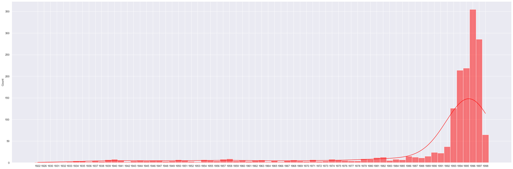

```python
# REALEASE YEAR
year=movie['release date']
year=year.str.split('-')
year=year.str[-1]

year=list(year)
year.sort()
sns.displot(year, rug=False, kde=True, height=10, aspect=3,color="red");
plt.show()
```

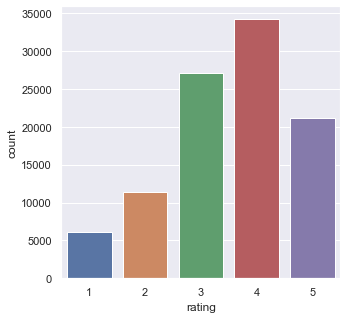

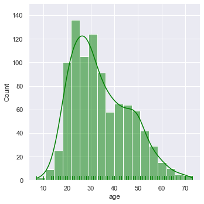

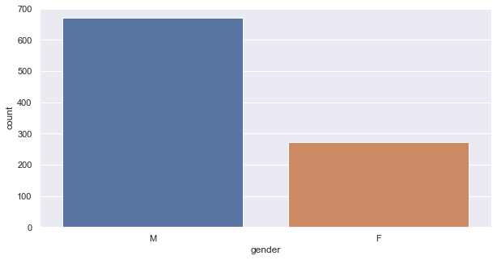

```python
# RATING - countplot
sns.set({'figure.figsize': (5,5)})
sns.countplot(data=data, x='rating');
plt.show()

# AGE -- distplot for age
# Per the Seaborn, this is no longer used so will be using displot
#  https://seaborn.pydata.org/generated/seaborn.distplot.html
#  This function is deprecated and will be removed in a future version. Please adapt your code to use one of two new functions:
#  displot(), a figure-level function with a similar flexibility over the kind of plot to draw
#  histplot(), an axes-level function for plotting histograms, including with kernel density smoothing
sns.set({'figure.figsize': (15,5)})
sns.displot(user['age'], rug=True, kde=True, color="green");
plt.show()

# GENDER
sns.set({'figure.figsize': (10,5)})
sns.countplot(user['gender']);
plt.show()
```

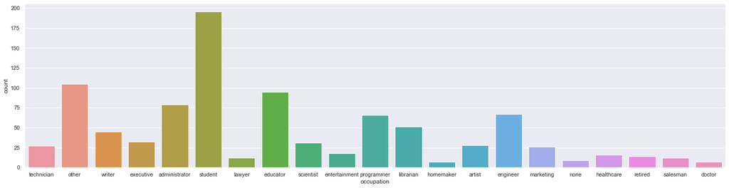

```python
# OCCUPATION
sns.set({'figure.figsize': (25,6)})
sns.countplot(data=user, x='occupation');
```

### 8. Visualize how popularity of genres has changed over the years - 10 marks

Note that you need to use the **percent of number of releases in a year** as a parameter of popularity of a genre

Hint 1: You need to reach to a data frame where the release year is the index and the genre is the column names (one cell shows the number of release in a year in one genre) or vice versa. (Drop unnecessary column if there are any)

Hint 2: Find the total number of movies release in a year(use item dataset to get count of movies released in a particular year, store that value in a new column as 'total'). Now divide the value of each genre in that year by total to get percentage number of release in a particular year. `(df.div(df['total'], axis= 0) * 100)`

Once that is achieved, you can either use univariate plots or can use the heatmap to visualise all the changes over the years in one go.

Hint 3: Use groupby on the relevant column and use sum() on the same to find out the number of releases in a year/genre.

```python
year=movie['release date'].str.split('-').str[-1]
cleanMovie=movie.copy()
cleanMovie.drop(['release date', 'movie title'], axis=1, inplace=True)
cleanMovie=pd.merge(cleanMovie,year, how='inner', on='movie id')
cleanMovie.rename(columns={'release date': 'Year'}, inplace=True)
```

```python
GroupYear=cleanMovie.groupby(by="Year").sum() #this seemed more elegant
GroupYear.sort_values(by='Year')
```

| Year | Action | Adventure | Animation | Childrens | Comedy | Crime | Documentary | Drama | Fantasy | Film-Noir | Horror | Musical | Mystery | Romance | Sci-Fi | Thriller | War | Western |
| --- | --- | --- | --- | --- | --- | --- | --- | --- | --- | --- | --- | --- | --- | --- | --- | --- | --- | --- |
| 1922 | 0 | 0 | 0 | 0 | 0 | 0 | 0 | 0 | 0 | 0 | 1 | 0 | 0 | 0 | 0 | 0 | 0 | 0 |
| 1926 | 0 | 0 | 0 | 0 | 0 | 0 | 0 | 1 | 0 | 0 | 0 | 0 | 0 | 0 | 0 | 0 | 0 | 0 |
| 1930 | 0 | 0 | 0 | 0 | 0 | 0 | 0 | 1 | 0 | 0 | 0 | 0 | 0 | 0 | 0 | 0 | 0 | 0 |
| 1931 | 0 | 0 | 0 | 0 | 0 | 1 | 0 | 0 | 0 | 1 | 0 | 0 | 0 | 0 | 0 | 1 | 0 | 0 |
| 1932 | 0 | 0 | 0 | 0 | 0 | 0 | 0 | 0 | 0 | 0 | 0 | 0 | 0 | 1 | 0 | 0 | 1 | 0 |
| ... | ... | ... | ... | ... | ... | ... | ... | ... | ... | ... | ... | ... | ... | ... | ... | ... | ... | ... |
| 1994 | 30 | 13 | 4 | 15 | 82 | 8 | 9 | 97 | 3 | 0 | 8 | 2 | 2 | 35 | 7 | 25 | 7 | 6 |
| 1995 | 40 | 22 | 6 | 21 | 63 | 11 | 5 | 89 | 3 | 1 | 14 | 3 | 5 | 37 | 15 | 39 | 5 | 2 |
| 1996 | 44 | 24 | 9 | 21 | 108 | 21 | 18 | 170 | 6 | 1 | 11 | 9 | 6 | 38 | 15 | 47 | 9 | 2 |
| 1997 | 46 | 20 | 3 | 22 | 87 | 30 | 6 | 113 | 4 | 2 | 8 | 5 | 18 | 51 | 13 | 54 | 14 | 0 |
| 1998 | 12 | 3 | 0 | 1 | 13 | 7 | 3 | 33 | 1 | 2 | 4 | 1 | 3 | 11 | 5 | 18 | 0 | 0 |

71 rows × 18 columns

```python
divide=cleanMovie['Year'].value_counts(normalize=True)
```

```python
plotme=GroupYear.div(divide,axis=0)
plotmeT=plotme.transpose()
```

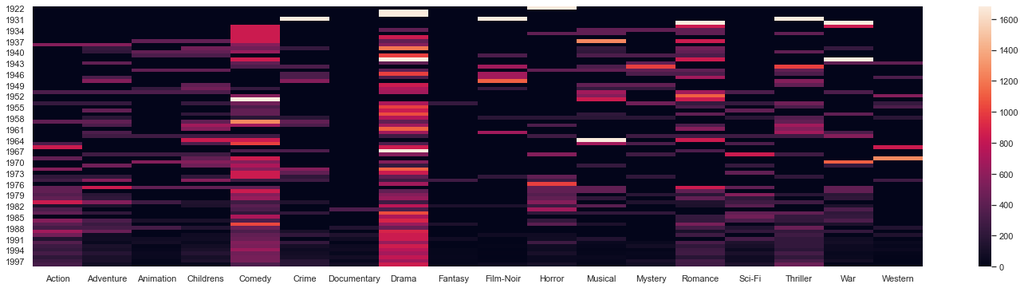

```python
# sns.set({'figure.figsize': (25,6)})
sns.heatmap(plotme);
plt.show()
```

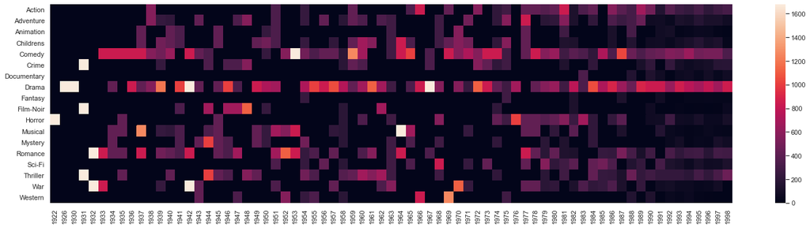

```python
# sns.set({'figure.figsize': (25,6)})
sns.heatmap(plotmeT);
plt.show()
```

### 9. Find the top 25 movies in terms of average ratings for movies that have been rated more than 100 times - 10 marks

Hints :

1. Find the count of ratings and average ratings for every movie.
2. Slice the movies which have ratings more than 100.
3. Sort values according to average rating such that movie which highest rating is on top.
4. Select top 25 movies.
5. You will have to use the .merge() function to get the movie titles.

Note: This question will need you to research about groupby and apply your findings. You can find more on groupby on https://realpython.com/pandas-groupby/.

```python
data_backup=data.copy()
# Its important to back up the data when making modifications for future use.
```

```python
data.drop(['timestamp','user id'], axis=1, inplace=True)
# 1. Find the count of ratings and average ratings for every movie.
data.sort_values(by='movie id',inplace=True)
AvgRating=pd.pivot_table(data, aggfunc='mean', index="movie id")
SumRating=pd.pivot_table(data, aggfunc='sum', index="movie id")
RankRating=pd.merge(SumRating, AvgRating, how='inner', on='movie id')
RankRating.rename(columns={"rating_x": "total ratings", "rating_y": "average rating"}, inplace=True)

# 2. Slice the movies which have ratings more than 100.
RankRating = RankRating[RankRating['total ratings']>100]
RankRating.sort_values(by='total ratings',inplace=False);

# 3. Sort values according to average rating such that movie which highest rating is on top.
RankRating.sort_values(by='average rating', ascending=False, inplace=True)

# 4. Select top 25 movies.
Top25=RankRating[0:25]
Top25.reset_index()
```

|  | movie id | total ratings | average rating |
| --- | --- | --- | --- |
| 0 | 408 | 503 | 4.491071 |
| 1 | 318 | 1331 | 4.466443 |
| 2 | 169 | 527 | 4.466102 |
| 3 | 483 | 1083 | 4.456790 |
| 4 | 114 | 298 | 4.447761 |
| 5 | 64 | 1258 | 4.445230 |
| 6 | 603 | 917 | 4.387560 |
| 7 | 12 | 1171 | 4.385768 |
| 8 | 50 | 2541 | 4.358491 |
| 9 | 178 | 543 | 4.344000 |
| 10 | 513 | 312 | 4.333333 |
| 11 | 134 | 850 | 4.292929 |
| 12 | 963 | 176 | 4.292683 |
| 13 | 427 | 940 | 4.292237 |
| 14 | 357 | 1133 | 4.291667 |
| 15 | 98 | 1673 | 4.289744 |
| 16 | 480 | 767 | 4.284916 |
| 17 | 127 | 1769 | 4.283293 |
| 18 | 285 | 691 | 4.265432 |
| 19 | 272 | 844 | 4.262626 |
| 20 | 251 | 196 | 4.260870 |
| 21 | 657 | 558 | 4.259542 |
| 22 | 474 | 825 | 4.252577 |
| 23 | 174 | 1786 | 4.252381 |
| 24 | 479 | 761 | 4.251397 |

```python
RankRating=pd.merge(RankRating, movie['movie title'], how='inner', on='movie id')
RankRating
```

| movie id | total ratings | average rating | movie title |
| --- | --- | --- | --- |
| 408 | 503 | 4.491071 | Close Shave, A |
| 318 | 1331 | 4.466443 | Schindler's List |
| 169 | 527 | 4.466102 | Wrong Trousers, The |
| 483 | 1083 | 4.456790 | Casablanca |
| 114 | 298 | 4.447761 | Wallace & Gromit: The Best of Aardman Animation |
| ... | ... | ... | ... |
| 1079 | 101 | 2.244444 | Joe's Apartment |
| 120 | 150 | 2.238806 | Striptease |
| 687 | 151 | 2.188406 | McHale's Navy |
| 948 | 104 | 2.166667 | Booty Call |
| 931 | 123 | 2.157895 | Island of Dr. Moreau, The |

768 rows × 3 columns

### 10. Check for the validity of the below statements with respect to the data provided - 10 marks

- Men watch more drama than women
- Women watch more Sci-Fi than men
- Men watch more Romance than women

**compare the percentages** **Please pay attention to what should be the denominator while calculating percentages**

```python
# 1. Merge all the datasets
# MergedDataSets MDS
movie = movie_backup.copy()
data = data_backup.copy()
MDS = pd.merge(user,data, how='inner', on='user id')
MDS = pd.merge(MDS, movie, how='inner', on='movie id')
MDS_backup=MDS.copy()
MDS=MDS.drop(['age', 'occupation', 'zip code', 'timestamp', 'movie title','movie id', 'release date','unknown'] , axis=1)
MDS
# SumRating=pd.pivot_table(MDS, aggfunc='sum', index="gender")*100
#this was more elegant than groupby
SumRating=pd.pivot_table(MDS, aggfunc='mean', index="gender")*100
SumRating.drop(['user id','rating'] , axis=1)
```

| gender | Action | Adventure | Animation | Childrens | Comedy | Crime | Documentary | Drama | Fantasy | Film-Noir | Horror | Musical | Mystery | Romance | Sci-Fi | Thriller | War | Western |
| --- | --- | --- | --- | --- | --- | --- | --- | --- | --- | --- | --- | --- | --- | --- | --- | --- | --- | --- |
| F | 21.143834 | 12.203745 | 3.865879 | 8.672002 | 31.346647 | 6.970239 | 0.726552 | 42.769446 | 1.410366 | 1.495843 | 4.650711 | 5.602611 | 5.105292 | 22.760121 | 10.214469 | 19.760665 | 8.504934 | 1.441448 |
| M | 27.132910 | 14.291678 | 3.515009 | 6.666397 | 29.310600 | 8.431983 | 0.768992 | 38.903479 | 1.331933 | 1.815415 | 5.548597 | 4.729775 | 5.294062 | 18.319799 | 13.603491 | 22.606494 | 9.708699 | 1.997226 |

**Conclusion:**

- It is FALSE that Men watch more drama than women
- It is FALSE that Women watch more Sci-Fi than men
- It is FALSE that Men watch more Romance than women